# Analyzing and Visualizing Data Report

This part is very importannt because it helps the stakeholder to better understand, observe the analysis that has been carried out.

The libraries that was used are **Matplotlib and Seaborn.**

Matplotlib is easy to use, low-level data visualization library that is built on NumPy arrays. It consists of various plots like scatter plot, line plot, histogram, etc. Matplotlib provides a lot of flexibility.

Seaborn is a high-level interface built on top of the Matplotlib. It provides beautiful design styles and color palettes to make more attractive graphs.

In this section, using the wrangled data I was able to analyze and visualize the following insights:

1. What are the top 10 most tweeted breed of dog? For this question, I considered only the predicted observations for dog breed by using the query function. The top 10 breed of dogs are the **Golden retriver,Labrador retriver,Pembroke,Chihuahua,Pug,Samoyed,Chow,Pomeranian,Toy poodle,Malamute.**

I displayed the result above in a bar chart using matplotlib libraries as below.

1. What is the most common breed of dog?

I found out after the analysis that the most common breed of dog is the **Golden retriver which has a total of 150 tweets.

1. What is the relationship between retweet and favorite count? The Retweet and Fvorite are correlated.

To show the corrolation between retweet and favorite count the Regression plot was used to display the relationship using seaborn. The regplot creates a regression line between 2 parameters and helps to visualize their linear relationships.

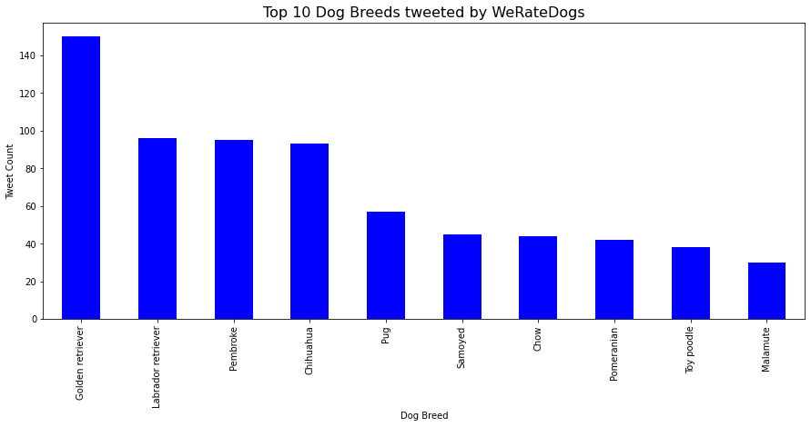

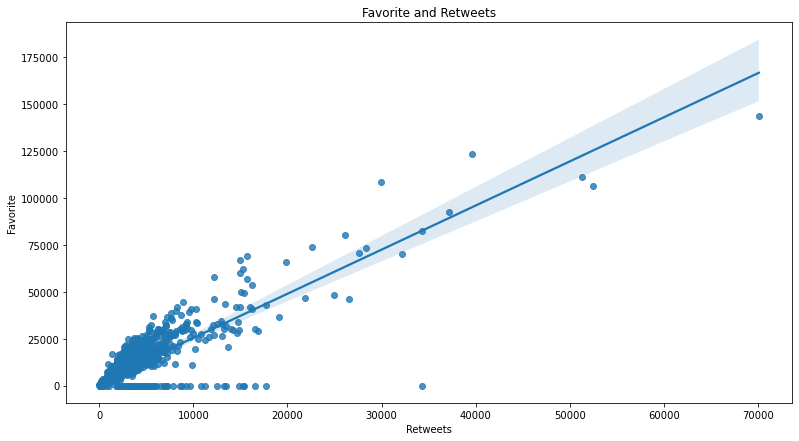

## Reference Links

[Matplotlib](https://www.geeksforgeeks.org/data-visualization-with-python/)

[Seaborn](https://www.geeksforgeeks.org/data-visualization-with-python/)